# First RQ of SCL30a DEGs

Dale Richardson

December 30, 2016

## Description

Here I will experiment with the https://cran.r-project.org/web/packages/MCMC.qpcr/index.html from Mikhail V. Matz.

From the Reference Manual:

*Quantitative RT-PCR data are analyzed using generalized linear mixed models based on lognormal-Poisson error distribution, fitted using MCMC. Control genes are not required but can be incorporated as Bayesian priors or, when template abundances correlate with conditions, as trackers of global effects (common to all genes). The package also implements a lognormal model for higher-abundance data and a “classic” model involving multigene normalization on a by-sample basis. Several plotting functions are included to extract and visualize results. The detailed tutorial is available here: http://bit.ly/1Nwo4CB.*

## Data processing

```r
## load the MCMC qpcr package, dplyr and tidyr
library(MCMC.qpcr)
library(dplyr)
library(tidyr)

## read in the qpcr input data files
## Skip the first 11 lines, which contain comments and set na.strings
myData <- read.csv("Well\ Results.csv", header = TRUE, skip = 11, na.strings = c("","-", "Undetermined")) %>%
        select(sample = Sample.Name, gene = Target.Name, Cq) %>%
        filter(sample != "No Sample", gene!= "GA20")

## write out simpler output
write.csv(myData, file = "tmp.csv", row.names = FALSE, quote = FALSE)
```

With the file, `tmp.csv`, I have used excel to rearrange the data so that it is in a wider format in accordance with the example data frame of the MCMC.qpcr tutorial. This file is called, `mcmc_formatted_RQ.csv`. I should spend some time doing this in R so that the analysis is fully reproducible…

```r
## load in the processed csv files
## efficiencies
eff <- read.csv("efficiency_updated.csv", header = TRUE, stringsAsFactors = FALSE)

## cqs
rq.data <- read.csv("mcmc_formatted_RQ.csv", header = TRUE, stringsAsFactors = FALSE)
```

From the tutorial:

*Recalculating the data into molecule counts and reformatting: One of the central ideas of the MCMC.qpcr methodology is to treat qPCR data as molecule count data. Function `cq2counts()` does the reformatting. It needs to be told the name of the main dataset, the name of efficiencies dataset, and also which columns correspond to the actual qPCR data for genes (‘genecols‘) and which columns contain experimental conditions (‘condcols‘): `qs=cq2counts(data=beckham.data, effic=beckham.eff, genecols=c(4:13),condcols=c(1:3))`*

## Running the model

```r
## recalculate data into molecule counts and reformat
qs <- cq2counts(data = rq.data, effic = eff, genecols = c(4:13), condcols = c(1:3), Cq1 = 37)

## on previous runs, i saw that the plateau of acceptance values was reached at iteration 4000.
## therefore, I need to change the nitt=14000 and burnin=4000.
## hiding the model sanity check output
informed_d <- mcmc.qpcr(
        fixed = "condition+genotype",
        random = "sample",
        data = qs,
        controls = c("ef1a", "ubc21"),
        m.fix = 1.2,
        pr = TRUE,
        pl = TRUE,
        nitt = 14000,
        burnin = 4000
)
```

## Diagnostic check if linear modeling approach is valid

```r
## check if linear modeling approach is valid
## residuaals vs predicted should show no trend, if does then data are not linear
## size of residuals should not change depending on predicted value (test for equal variances across the modeled range)
## residuals should be approximately normally distributed

diagnostic.mcmc(
        model = informed_d,
        col = "grey50",
        cex = 0.8
)
```

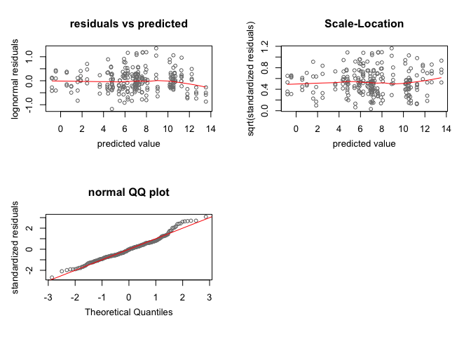

From the above plots, it appears that the linear modeling approach is indeed valid.

## Gene expression plots

I still need to annotate the resulting plots with asterisks to denote signficance.

```r
## trellisbyGene
smm2 <- HPDsummary(informed_d,qs,xgroup="genotype")
```

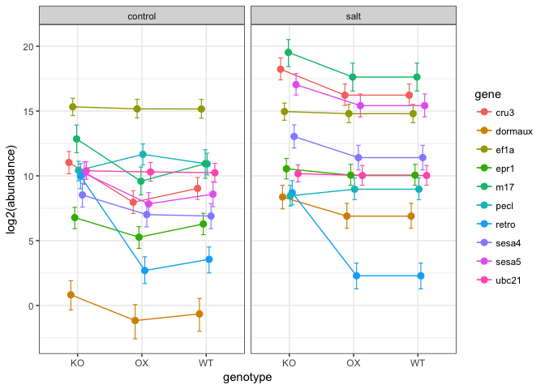

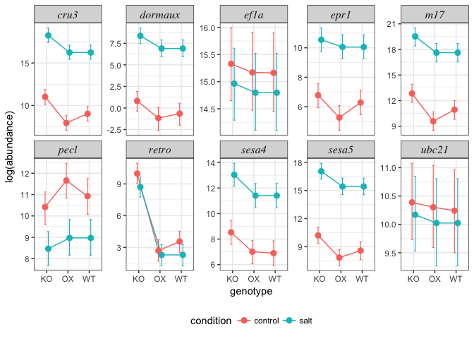

```r
trellisByGene(smm2,xFactor="genotype",groupFactor="condition")+xlab("genotype")
```

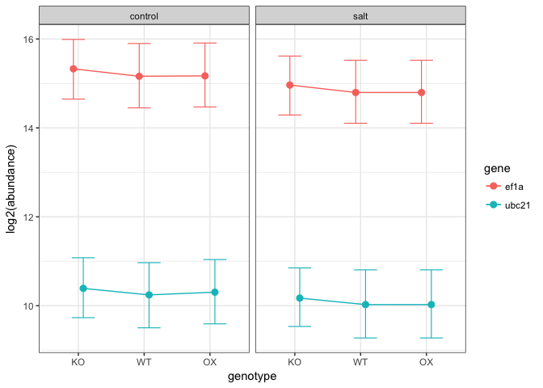

```
## $summary
##     gene condition genotype     mean        sd     lower    upper
## 1   ef1a   control       KO 15.32889 0.4359876 14.648275 15.99007
## 2   ef1a   control       OX 15.16985 0.4469780 14.471916 15.90935
## 3   ef1a   control       WT 15.16171 0.4561234 14.450526 15.89850
## 4   ef1a      salt       KO 14.96402 0.4073688 14.289991 15.61647
## 5   ef1a      salt       OX 14.79684 0.4466322 14.103692 15.52232
## 6   ef1a      salt       WT 14.79684 0.4466322 14.103692 15.52232
## 7  ubc21   control       KO 10.38869 0.4182207  9.730474 11.07770
## 8  ubc21   control       OX 10.30369 0.4556970  9.590521 11.03822
## 9  ubc21   control       WT 10.24239 0.4576638  9.502009 10.96704
## 10 ubc21      salt       KO 10.17042 0.4130879  9.532271 10.85012
## 11 ubc21      salt       OX 10.02412 0.4702926  9.273521 10.80541
## 12 ubc21      salt       WT 10.02412 0.4702926  9.273521 10.80541
##
## $geneWise
## $geneWise$ef1a
##                              difference
## pvalue                        conditioncontrol:genotypeKO
##   conditioncontrol:genotypeKO                          NA
##   conditioncontrol:genotypeOX                       0.684
##   conditioncontrol:genotypeWT                       0.692
##   conditionsalt:genotypeKO                          0.376
##   conditionsalt:genotypeOX                          0.376
##   conditionsalt:genotypeWT                          0.376
##                              difference
## pvalue                        conditioncontrol:genotypeOX
##   conditioncontrol:genotypeKO                  -0.1590434
##   conditioncontrol:genotypeOX                          NA
##   conditioncontrol:genotypeWT                   0.9900000
##   conditionsalt:genotypeKO                      0.7440000
##   conditionsalt:genotypeOX                      0.5240000
##   conditionsalt:genotypeWT                      0.5240000
##                              difference
## pvalue                        conditioncontrol:genotypeWT
##   conditioncontrol:genotypeKO                -0.167186098
##   conditioncontrol:genotypeOX                -0.008142721
##   conditioncontrol:genotypeWT                          NA
##   conditionsalt:genotypeKO                    0.742000000
##   conditionsalt:genotypeOX                    0.376000000
```

[output cut: 63 more lines]

```
##   conditioncontrol:genotypeWT               -0.2182691
##   conditionsalt:genotypeKO                  -0.1462949
##   conditionsalt:genotypeOX                          NA
##   conditionsalt:genotypeWT                   0.0020000
##                              difference
## pvalue                        conditionsalt:genotypeWT
##   conditioncontrol:genotypeKO               -0.3645640
##   conditioncontrol:genotypeOX               -0.2795635
##   conditioncontrol:genotypeWT               -0.2182691
##   conditionsalt:genotypeKO                  -0.1462949
##   conditionsalt:genotypeOX                   0.0000000
##   conditionsalt:genotypeWT                          NA
##
##
## $ggPlot
```

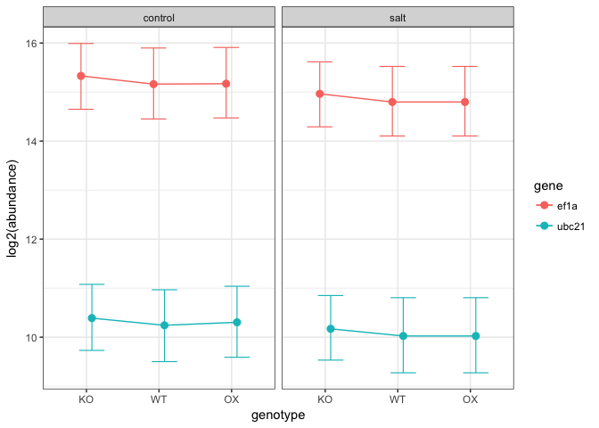

```r
## test plots
## housekeepers only
HPDsummary(model = informed_d, data = qs, xgroup = "genotype", genes = c("ef1a", "ubc21"), x.order = c("KO", "WT", "OX"), ptype="mcmc")
```

```r
## now one by one
# HPDsummary(model = informed_d, data = qs, xgroup = "genotype", genes = c("retro"),
#            x.order = c("KO", "WT", "OX"), ptype="mcmc")
# HPDsummary(model = informed_d, data = qs, xgroup = "genotype", genes = c("sesa4"),
#            x.order = c("KO", "WT", "OX"), ptype="mcmc")
# HPDsummary(model = informed_d, data = qs, xgroup = "genotype", genes = c("sesa5"),
#            x.order = c("KO", "WT", "OX"), ptype="mcmc")
# HPDsummary(model = informed_d, data = qs, xgroup = "genotype", genes = c("m17"),
#            x.order = c("KO", "WT", "OX"), ptype="mcmc")
# HPDsummary(model = informed_d, data = qs, xgroup = "genotype", genes = c("epr1"),
#            x.order = c("KO", "WT", "OX"), ptype="mcmc")
# HPDsummary(model = informed_d, data = qs, xgroup = "genotype", genes = c("pecl"),
#            x.order = c("KO", "WT", "OX"), ptype="mcmc")
# HPDsummary(model = informed_d, data = qs, xgroup = "genotype", genes = c("cru3"),
#            x.order = c("KO", "WT", "OX"), ptype="mcmc")
# HPDsummary(model = informed_d, data = qs, xgroup = "genotype", genes = c("dormaux"),
#            x.order = c("KO", "WT", "OX"), ptype="mcmc")

## filtering
## get the plotting data out of the summary object
ggplotData <- smm2$ggPlot$data
## refactor to put genotype in right order
ggplotData$genotype <- factor(ggplotData$genotype, levels = c("KO", "WT", "OX"))

## pull out individual genes
retro <- ggplotData %>% filter(gene == "retro")
cru3 <- ggplotData %>% filter(gene == "cru3")
sesa4 <- ggplotData %>% filter(gene == "sesa4")
sesa5 <- ggplotData %>% filter(gene == "sesa5")
m17 <- ggplotData %>% filter(gene == "m17")
epr1 <- ggplotData %>% filter(gene == "epr1")
pecl <- ggplotData %>% filter(gene == "pecl")
dormaux <- ggplotData %>% filter(gene == "dormaux")
```

## Individual Gene Plots

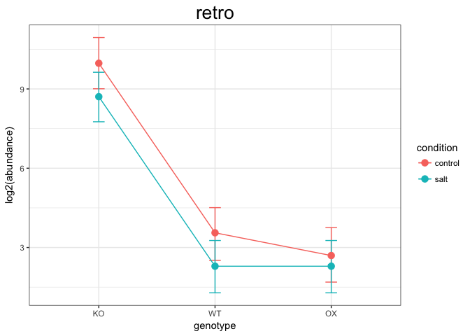

```r
ggplot(retro, aes(x = genotype, y = mean, colour = condition, group = condition)) +
        geom_errorbar(aes(ymin = lower, ymax = upper), width = 0.1) +
        geom_line() +
        geom_point(size = 3) +
        ylab("log2(abundance)") +
        ggtitle("retro") +
        theme_bw() +
        theme(plot.title = element_text(size = 20, hjust=0.5))
```

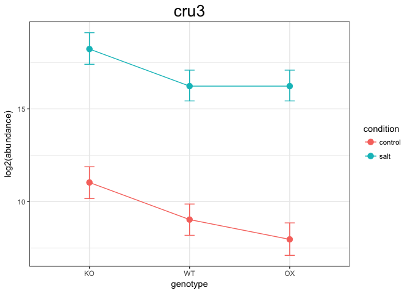

```r
ggplot(cru3, aes(x = genotype, y = mean, colour = condition, group = condition)) +
        geom_errorbar(aes(ymin = lower, ymax = upper), width = 0.1) +
        geom_line() +
        geom_point(size = 3) +
        ylab("log2(abundance)") +
        ggtitle("cru3") +
        theme_bw() +
        theme(plot.title = element_text(size = 20, hjust=0.5))
```

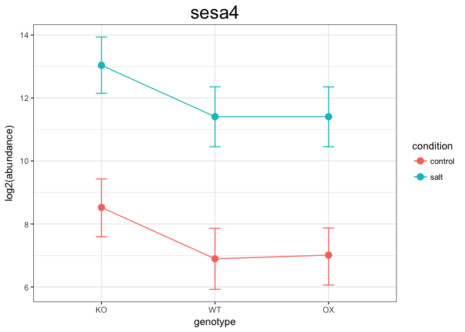

```r
ggplot(sesa4, aes(x = genotype, y = mean, colour = condition, group = condition)) +
        geom_errorbar(aes(ymin = lower, ymax = upper), width = 0.1) +
        geom_line() +
        geom_point(size = 3) +
        ylab("log2(abundance)") +
        ggtitle("sesa4") +
        theme_bw() +
        theme(plot.title = element_text(size = 20, hjust=0.5))
```

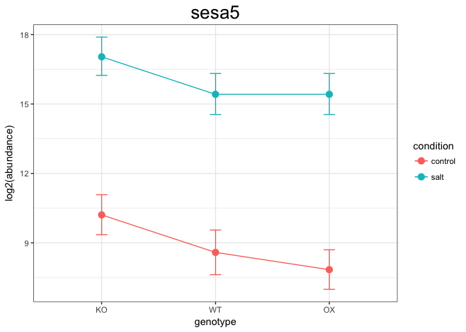

```r
ggplot(sesa5, aes(x = genotype, y = mean, colour = condition, group = condition)) +
        geom_errorbar(aes(ymin = lower, ymax = upper), width = 0.1) +
        geom_line() +
        geom_point(size = 3) +
        ylab("log2(abundance)") +
        ggtitle("sesa5") +
        theme_bw() +
        theme(plot.title = element_text(size = 20, hjust=0.5))
```

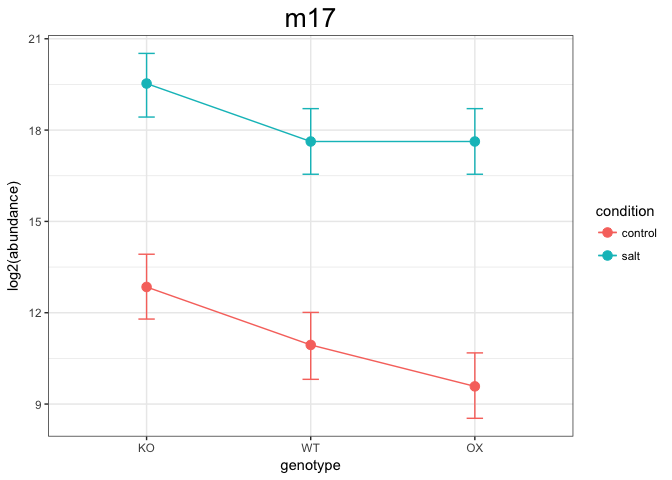

```r
ggplot(m17, aes(x = genotype, y = mean, colour = condition, group = condition)) +
        geom_errorbar(aes(ymin = lower, ymax = upper), width = 0.1) +
        geom_line() +
        geom_point(size = 3) +
        ylab("log2(abundance)") +
        ggtitle("m17") +
        theme_bw() +
        theme(plot.title = element_text(size = 20, hjust=0.5))
```

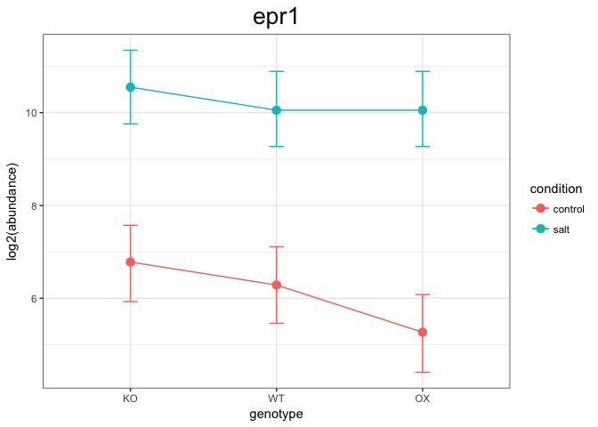

```r
ggplot(epr1, aes(x = genotype, y = mean, colour = condition, group = condition)) +
        geom_errorbar(aes(ymin = lower, ymax = upper), width = 0.1) +
        geom_line() +
        geom_point(size = 3) +
        ylab("log2(abundance)") +
        ggtitle("epr1") +
        theme_bw() +
        theme(plot.title = element_text(size = 20, hjust=0.5))
```

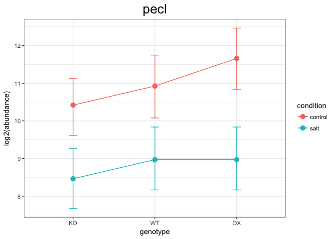

```r
ggplot(pecl, aes(x = genotype, y = mean, colour = condition, group = condition)) +
        geom_errorbar(aes(ymin = lower, ymax = upper), width = 0.1) +
        geom_line() +
        geom_point(size = 3) +
        ylab("log2(abundance)") +
        ggtitle("pecl") +
        theme_bw() +
        theme(plot.title = element_text(size = 20, hjust=0.5))
```

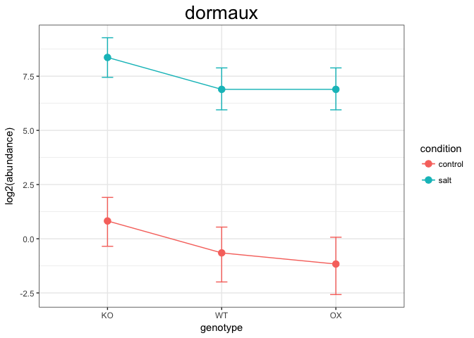

```r
ggplot(dormaux, aes(x = genotype, y = mean, colour = condition, group = condition)) +
        geom_errorbar(aes(ymin = lower, ymax = upper), width = 0.1) +
        geom_line() +
        geom_point(size = 3) +
        ylab("log2(abundance)") +
        ggtitle("dormaux") +
        theme_bw() +
        theme(plot.title = element_text(size = 20, hjust=0.5))
```

## Statistical significance

```r
smm2$geneWise
```

```
## $cru3
##                              difference
## pvalue                        conditioncontrol:genotypeKO
##   conditioncontrol:genotypeKO                          NA
##   conditioncontrol:genotypeOX                1.783150e-06
##   conditioncontrol:genotypeWT                1.195851e-03
##   conditionsalt:genotypeKO                   0.000000e+00
##   conditionsalt:genotypeOX                   2.044720e-10
##   conditionsalt:genotypeWT                   2.044720e-10
##                              difference
## pvalue                        conditioncontrol:genotypeOX
##   conditioncontrol:genotypeKO                 -3.06887868
##   conditioncontrol:genotypeOX                          NA
##   conditioncontrol:genotypeWT                  0.09396711
##   conditionsalt:genotypeKO                     0.00000000
##   conditionsalt:genotypeOX                     0.00000000
##   conditionsalt:genotypeWT                     0.00000000
##                              difference
## pvalue                        conditioncontrol:genotypeWT
##   conditioncontrol:genotypeKO                   -2.000824
##   conditioncontrol:genotypeOX                    1.068055
##   conditioncontrol:genotypeWT                          NA
##   conditionsalt:genotypeKO                       0.000000
##   conditionsalt:genotypeOX                       0.000000
##   conditionsalt:genotypeWT                       0.000000
##                              difference
## pvalue                        conditionsalt:genotypeKO
##   conditioncontrol:genotypeKO              7.196014416
##   conditioncontrol:genotypeOX             10.264893100
##   conditioncontrol:genotypeWT              9.196838568
##   conditionsalt:genotypeKO                          NA
##   conditionsalt:genotypeOX                 0.001195851
##   conditionsalt:genotypeWT                 0.001195851
##                              difference
## pvalue                        conditionsalt:genotypeOX
##   conditioncontrol:genotypeKO                 5.195190
##   conditioncontrol:genotypeOX                 8.264069
##   conditioncontrol:genotypeWT                 7.196014
##   conditionsalt:genotypeKO                   -2.000824
##   conditionsalt:genotypeOX                          NA
```

[output cut: 444 more lines]

```
## pvalue                        conditionsalt:genotypeOX
##   conditioncontrol:genotypeKO               -0.5320553
##   conditioncontrol:genotypeOX               -0.3730120
##   conditioncontrol:genotypeWT               -0.3648692
##   conditionsalt:genotypeKO                  -0.1671861
##   conditionsalt:genotypeOX                          NA
##   conditionsalt:genotypeWT                         NaN
##                              difference
## pvalue                        conditionsalt:genotypeWT
##   conditioncontrol:genotypeKO               -0.5320553
##   conditioncontrol:genotypeOX               -0.3730120
##   conditioncontrol:genotypeWT               -0.3648692
##   conditionsalt:genotypeKO                  -0.1671861
##   conditionsalt:genotypeOX                   0.0000000
##   conditionsalt:genotypeWT                          NA
```